# EDA for the Pneumonia Dataset

```python
import pandas as pd
import numpy as np
import matplotlib
import matplotlib.pyplot as plt
from tqdm import tqdm_notebook
from matplotlib.patches import Rectangle
import seaborn as sns
import pydicom as dcm
import os
%matplotlib inline
IS_LOCAL = False

# Root directory of the project
PROJ_DIR = "E:\\DCM-IMG"
ROOT_DIR = os.path.abspath(PROJ_DIR +'\\data')
ORIG_DATA_DIR = os.path.abspath(PROJ_DIR +'\\Archive')
if(IS_LOCAL):
    PATH=PROJ_DIR
else:
    PATH=PROJ_DIR
print(os.listdir(PATH))
```

```
['Archive', 'data', 'GCP Credits Request Link - RSNA.txt', 'Temp']
```

Load the data Let's load the tabular data. There are two files:

Detailed class info; Train labels.

```python
class_info_df = pd.read_csv(ROOT_DIR+'/stage_2_detailed_class_info.csv')
train_labels_df = pd.read_csv(ROOT_DIR+'/stage_2_train_labels.csv')
```

```python
print(f"Detailed class info -  rows: {class_info_df.shape[0]}, columns: {class_info_df.shape[1]}")
print(f"Train labels -  rows: {train_labels_df.shape[0]}, columns: {train_labels_df.shape[1]}")
```

```
Detailed class info -  rows: 30227, columns: 2
Train labels -  rows: 30227, columns: 6
```

# Explore the two loaded files. We will take out a 5 rows samples from each dataset.

```python
class_info_df.sample(5)
```

|  | patientId | class |
| --- | --- | --- |
| 5617 | 482892b3-63bf-44f3-bd81-8079889f7b4f | No Lung Opacity / Not Normal |
| 12490 | 7f4d7003-5743-4747-91d2-87d52ade47e7 | No Lung Opacity / Not Normal |
| 30175 | c08f10a9-1c81-4c81-b411-a53c7b51f20b | Lung Opacity |
| 6135 | 4c6c4d5f-f0f7-4531-b9b0-d52d7d59f3ed | No Lung Opacity / Not Normal |
| 11794 | 79a9b7e9-e836-49b8-9959-025907fe10bb | No Lung Opacity / Not Normal |

```python
train_labels_df.sample(5)
```

|  | patientId | x | y | width | height | Target |
| --- | --- | --- | --- | --- | --- | --- |
| 6974 | 53367958-ef11-4c3e-a2f3-374e88dfbd90 | NaN | NaN | NaN | NaN | 0 |
| 21906 | c67e19ae-3f15-408e-9186-767a4c8e3bca | NaN | NaN | NaN | NaN | 0 |
| 3404 | 38266a50-cf99-4476-884a-da94f3c51cba | NaN | NaN | NaN | NaN | 0 |
| 2673 | 336c9afc-e140-4d5e-ab50-7b11809dbc1f | 117.0 | 553.0 | 226.0 | 341.0 | 1 |
| 10248 | 6db9b51e-72d8-4511-b113-fa0ef0387fe3 | NaN | NaN | NaN | NaN | 0 |

In class detailed info dataset are given the detailed information about the type of positive or negative class associated with a certain patient.#

In train labels dataset are given the patient ID and the window (x min, y min, width and height of the) containing evidence of pneumonia.

# Data exploration

```python
# Finding the missing Information in the DataSet
```

```python
def missing_data(data):
    total = data.isnull().sum().sort_values(ascending = False)
    percent = (data.isnull().sum()/data.isnull().count()*100).sort_values(ascending = False)
    return np.transpose(pd.concat([total, percent], axis=1, keys=['Total', 'Percent']))
missing_data(train_labels_df)
```

|  | height | width | y | x | Target | patientId |
| --- | --- | --- | --- | --- | --- | --- |
| Total | 20672.000000 | 20672.000000 | 20672.000000 | 20672.000000 | 0.0 | 0.0 |
| Percent | 68.389188 | 68.389188 | 68.389188 | 68.389188 | 0.0 | 0.0 |

```python
missing_data(class_info_df)
```

|  | class | patientId |
| --- | --- | --- |
| Total | 0.0 | 0.0 |
| Percent | 0.0 | 0.0 |

# The percent missing for x,y, height and width in train labels represents the percent of the target 0 **(not** Lung opacity).

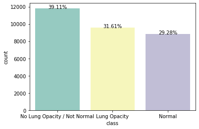

```python
f, ax = plt.subplots(1,1, figsize=(6,4))
total = float(len(class_info_df))
sns.countplot(class_info_df['class'],order = class_info_df['class'].value_counts().index, palette='Set3')
for p in ax.patches:
    height = p.get_height()
    ax.text(p.get_x()+p.get_width()/2.,
            height + 3,
            '{:1.2f}%'.format(100*height/total),
            ha="center")
plt.show()
```

```python
def get_feature_distribution(data, feature):
    # Get the count for each label
    label_counts = data[feature].value_counts()

    # Get total number of samples
    total_samples = len(data)

    # Count the number of items in each class
    print("Feature: {}".format(feature))
    for i in range(len(label_counts)):
        label = label_counts.index[i]
        count = label_counts.values[i]
        percent = int((count / total_samples) * 10000) / 100
        print("{:<30s}:   {} or {}%".format(label, count, percent))

get_feature_distribution(class_info_df, 'class')
```

```
Feature: class
No Lung Opacity / Not Normal  :   11821 or 39.1%
Lung Opacity                  :   9555 or 31.61%
Normal                        :   8851 or 29.28%
```

```python
#analysis the class informations
# Normal Category is 29.28 % and rest of the category is 70.72%
```

```python
# Merge train and class detail info data using the Patient ID
```

```python
train_class_df = train_labels_df.merge(class_info_df, left_on='patientId', right_on='patientId', how='inner')
```

```python
train_class_df.sample(5)
```

|  | patientId | x | y | width | height | Target | class |
| --- | --- | --- | --- | --- | --- | --- | --- |
| 22509 | ac380845-aaa5-4b00-ae45-dae7f44d8a40 | NaN | NaN | NaN | NaN | 0 | No Lung Opacity / Not Normal |
| 29849 | d4c8e2cd-9348-419f-91d0-524e6373d028 | NaN | NaN | NaN | NaN | 0 | No Lung Opacity / Not Normal |
| 25213 | b858e525-59a0-4e31-a893-6698f934c5cd | 616.0 | 310.0 | 256.0 | 514.0 | 1 | Lung Opacity |
| 37346 | 2d519447-4bcf-42ad-bb28-cf051b649fff | 673.0 | 751.0 | 227.0 | 136.0 | 1 | Lung Opacity |
| 14504 | 78228039-bc86-44ce-8a13-57cf49ccf493 | 638.0 | 256.0 | 147.0 | 214.0 | 1 | Lung Opacity |

```python
#Target and class¶
#Let's plot the number of examinations for each class detected, grouped by Target value.
```

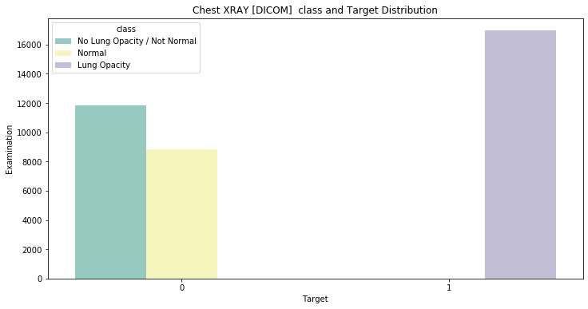

```python
fig, ax = plt.subplots(nrows=1,figsize=(12,6))
tmp = train_class_df.groupby('Target')['class'].value_counts()
df = pd.DataFrame(data={'Examination': tmp.values}, index=tmp.index).reset_index()
sns.barplot(ax=ax,x = 'Target', y='Examination',hue='class',data=df, palette='Set3')
plt.title("Chest XRAY [DICOM]  class and Target Distribution")
plt.show()
```

```python
#Data shows that withTarget = 1** (pathology detected) are mostly associated with class: **Lung Opacity.

#Data shows that with Target = 0** (no pathology detected) are either of  two class: **Normal or * No Lung Opacity / Not Normal.
```

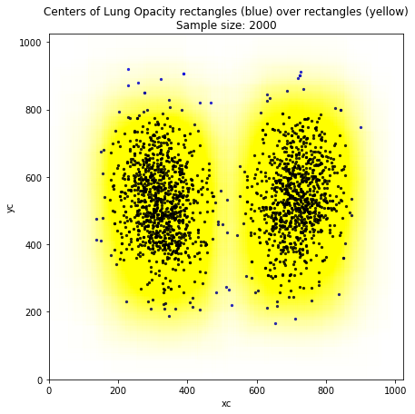

```python
target1 = train_class_df[train_class_df['Target']==1]
fig, ax = plt.subplots(1,1,figsize=(7,7))
target_sample = target1.sample(2000)
target_sample['xc'] = target_sample['x'] + target_sample['width'] / 2
target_sample['yc'] = target_sample['y'] + target_sample['height'] / 2
plt.title("Centers of Lung Opacity rectangles (blue) over rectangles (yellow)\nSample size: 2000")
target_sample.plot.scatter(x='xc', y='yc', xlim=(0,1024), ylim=(0,1024), ax=ax, alpha=0.8, marker=".", color="blue")
for i, crt_sample in target_sample.iterrows():
    ax.add_patch(Rectangle(xy=(crt_sample['x'], crt_sample['y']),
                width=crt_sample['width'],height=crt_sample['height'],alpha=3.5e-3, color="yellow"))
plt.show()
```

Exploring DICOM DATA

```python
image_sample_path = os.listdir(ORIG_DATA_DIR+'\stage_2_train_images')[:5]
print(image_sample_path)
```

```
['0004cfab-14fd-4e49-80ba-63a80b6bddd6.dcm', '000924cf-0f8d-42bd-9158-1af53881a557.dcm', '000db696-cf54-4385-b10b-6b16fbb3f985.dcm', '000fe35a-2649-43d4-b027-e67796d412e0.dcm', '001031d9-f904-4a23-b3e5-2c088acd19c6.dcm']
```

The files names are the patients IDs. Let's check how many images are in the train and test folders.

```python
image_train_path = os.listdir(ORIG_DATA_DIR+'\stage_2_train_images')
image_test_path = os.listdir(ORIG_DATA_DIR+'\stage_2_test_images')
print("Number of images in train set:", len(image_train_path),"\nNumber of images in test set:", len(image_test_path))
```

```
Number of images in train set: 26684
Number of images in test set: 3000
```

# Only a reduced number of images are present in the training set (26684), compared with the number of images in the train_df data (30227).

```python
#Checking duplicates in train dataset and class files
```

```python
print("Unique patientId in  train_class_df: ", train_class_df['patientId'].nunique())
```

```
Unique patientId in  train_class_df:  26684
```

# confirmed that the number of unique patientsId are equal with the number of DICOM images in the train set.

```python
tmp = train_class_df.groupby(['patientId','Target', 'class'])['patientId'].count()
df = pd.DataFrame(data={'Examination': tmp.values}, index=tmp.index).reset_index()
tmp = df.groupby(['Examination','Target','class']).count()
df2 = pd.DataFrame(data=tmp.values, index=tmp.index).reset_index()
df2.columns = ['Examination', 'Target','Class', 'Entries']
df2
```

|  | Examination | Target | Class | Entries |
| --- | --- | --- | --- | --- |
| 0 | 1 | 0 | No Lung Opacity / Not Normal | 11821 |
| 1 | 1 | 0 | Normal | 8851 |
| 2 | 1 | 1 | Lung Opacity | 2614 |
| 3 | 4 | 1 | Lung Opacity | 3266 |
| 4 | 9 | 1 | Lung Opacity | 119 |
| 5 | 16 | 1 | Lung Opacity | 13 |

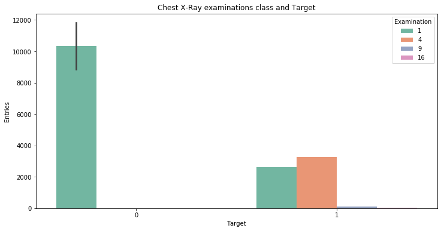

```python
fig, ax = plt.subplots(nrows=1,figsize=(12,6))
sns.barplot(ax=ax,x = 'Target', y='Entries', hue='Examination',data=df2, palette='Set2')
plt.title("Chest X-Ray examinations class and Target")
plt.show()
```

Exploring DICAM Data using DICAM Packages

```python
samplePatientID = list(train_class_df[:3].T.to_dict().values())[0]['patientId']
samplePatientID = samplePatientID+'.dcm'
dicom_file_path = os.path.join(PATH,ORIG_DATA_DIR+'\stage_2_train_images',samplePatientID)
dicom_file_dataset = dcm.read_file(dicom_file_path)
dicom_file_dataset
```

```
(0008, 0005) Specific Character Set              CS: 'ISO_IR 100'
(0008, 0016) SOP Class UID                       UI: Secondary Capture Image Storage
(0008, 0018) SOP Instance UID                    UI: 1.2.276.0.7230010.3.1.4.8323329.28530.1517874485.775526
(0008, 0020) Study Date                          DA: '19010101'
(0008, 0030) Study Time                          TM: '000000.00'
(0008, 0050) Accession Number                    SH: ''
(0008, 0060) Modality                            CS: 'CR'
(0008, 0064) Conversion Type                     CS: 'WSD'
(0008, 0090) Referring Physician's Name          PN: ''
(0008, 103e) Series Description                  LO: 'view: PA'
(0010, 0010) Patient's Name                      PN: '0004cfab-14fd-4e49-80ba-63a80b6bddd6'
(0010, 0020) Patient ID                          LO: '0004cfab-14fd-4e49-80ba-63a80b6bddd6'
(0010, 0030) Patient's Birth Date                DA: ''
(0010, 0040) Patient's Sex                       CS: 'F'
(0010, 1010) Patient's Age                       AS: '51'
(0018, 0015) Body Part Examined                  CS: 'CHEST'
(0018, 5101) View Position                       CS: 'PA'
(0020, 000d) Study Instance UID                  UI: 1.2.276.0.7230010.3.1.2.8323329.28530.1517874485.775525
(0020, 000e) Series Instance UID                 UI: 1.2.276.0.7230010.3.1.3.8323329.28530.1517874485.775524
(0020, 0010) Study ID                            SH: ''
(0020, 0011) Series Number                       IS: "1"
(0020, 0013) Instance Number                     IS: "1"
(0020, 0020) Patient Orientation                 CS: ''
(0028, 0002) Samples per Pixel                   US: 1
(0028, 0004) Photometric Interpretation          CS: 'MONOCHROME2'
(0028, 0010) Rows                                US: 1024
(0028, 0011) Columns                             US: 1024
(0028, 0030) Pixel Spacing                       DS: [0.14300000000000002, 0.14300000000000002]
(0028, 0100) Bits Allocated                      US: 8
(0028, 0101) Bits Stored                         US: 8
(0028, 0102) High Bit                            US: 7
(0028, 0103) Pixel Representation                US: 0
(0028, 2110) Lossy Image Compression             CS: '01'
(0028, 2114) Lossy Image Compression Method      CS: 'ISO_10918_1'
(7fe0, 0010) Pixel Data                          OB: Array of 142006 elements
```

useful information are there in the DICOM metadata like below

Patient sex; Patient age; Modality; Body part examined; View position; Rows & Columns; Pixel Spacing.

Plot DICOM images with Target = 1

```python
def show_dicom_images(data):
    img_data = list(data.T.to_dict().values())
    f, ax = plt.subplots(3,3, figsize=(16,18))
    for i,data_row in enumerate(img_data):
        patientImage = data_row['patientId']+'.dcm'
        imagePath = os.path.join(PATH,"\\DCM-IMG\\Archive\\stage_2_train_images",patientImage)
        print ("The image path is "+imagePath)
        data_row_img_data = dcm.read_file(imagePath)
        modality = data_row_img_data.Modality
        age = data_row_img_data.PatientAge
        sex = data_row_img_data.PatientSex
        data_row_img = dcm.dcmread(imagePath)
        ax[i//3, i%3].imshow(data_row_img.pixel_array, cmap=plt.cm.bone)
        ax[i//3, i%3].axis('off')
        ax[i//3, i%3].set_title('ID: {}\nModality: {} Age: {} Sex: {} Target: {}\nClass: {}\nWindow: {}:{}:{}:{}'.format(
                data_row['patientId'],
                modality, age, sex, data_row['Target'], data_row['class'],
                data_row['x'],data_row['y'],data_row['width'],data_row['height']))
    plt.show()

def show_dicom_images_with_boxes(data):
    img_data = list(data.T.to_dict().values())
    f, ax = plt.subplots(3,3, figsize=(16,18))
    for i,data_row in enumerate(img_data):
        patientImage = data_row['patientId']+'.dcm'
        imagePath = os.path.join(PATH,"\\DCM-IMG\\Archive\\stage_2_train_images",patientImage)
        data_row_img_data = dcm.read_file(imagePath)
        modality = data_row_img_data.Modality
        age = data_row_img_data.PatientAge
        sex = data_row_img_data.PatientSex
        data_row_img = dcm.dcmread(imagePath)
        ax[i//3, i%3].imshow(data_row_img.pixel_array, cmap=plt.cm.bone)
        ax[i//3, i%3].axis('off')
        ax[i//3, i%3].set_title('ID: {}\nModality: {} Age: {} Sex: {} Target: {}\nClass: {}'.format(
                data_row['patientId'],modality, age, sex, data_row['Target'], data_row['class']))
        rows = train_class_df[train_class_df['patientId']==data_row['patientId']]
        box_data = list(rows.T.to_dict().values())
        for j, row in enumerate(box_data):
            ax[i//3, i%3].add_patch(Rectangle(xy=(row['x'], row['y']),
                        width=row['width'],height=row['height'],
                        color="yellow",alpha = 0.1))
    plt.show()
```

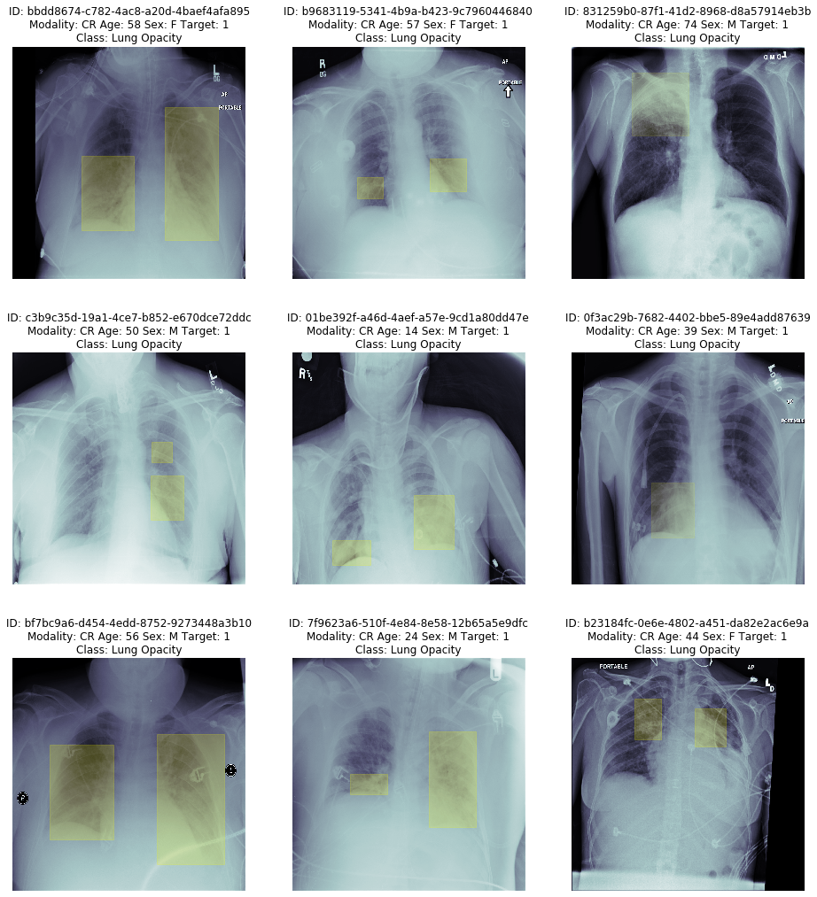

```python
show_dicom_images_with_boxes(train_class_df[train_class_df['Target']==1].sample(9))
```

[output not shown]

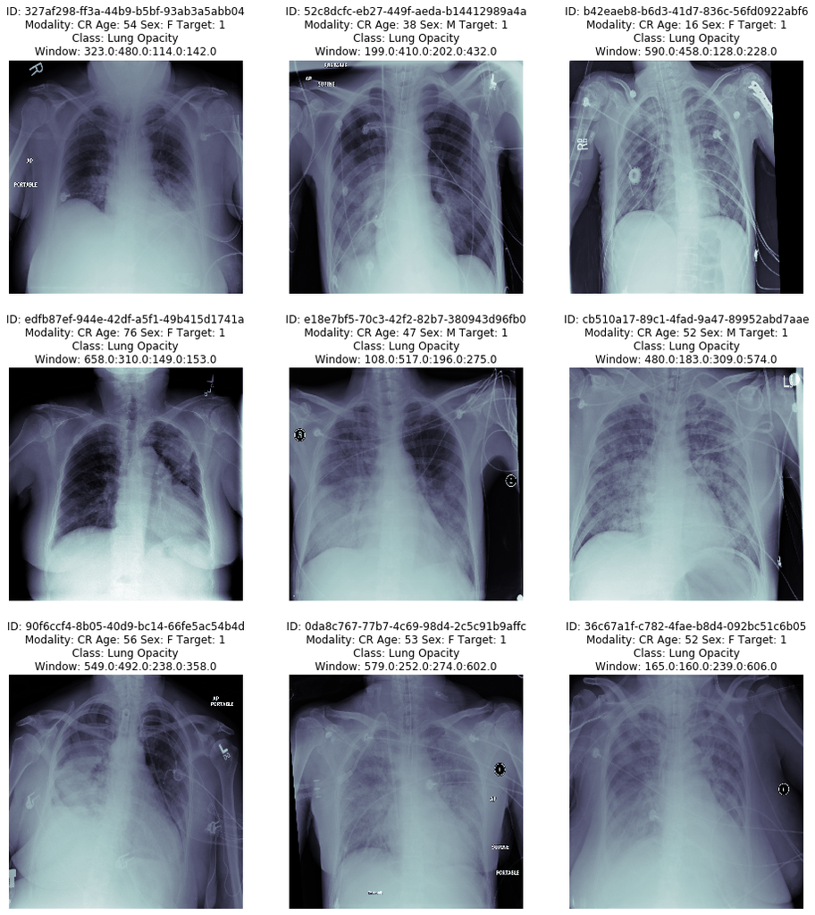

```python
show_dicom_images(train_class_df[train_class_df['Target']==1].sample(9))
```

```python
vars = ['Modality', 'PatientAge', 'PatientSex', 'BodyPartExamined', 'ViewPosition', 'ConversionType', 'Rows', 'Columns', 'PixelSpacing']

def process_dicom_data(data_df):
    for var in vars:
        data_df[var] = None
    image_names = os.listdir(PATH+"\\Archive\\stage_2_train_images\\")
    #print ("Path is "+PATH + " Data Path is "+data_path)
    #PATH_1 = "E:\DCM-IMG"
    for i, img_name in tqdm_notebook(enumerate(image_names)):
        #imagePath = os.path.join(PATH_1,data_path,img_name)
        imagePath = os.path.join(PATH,"\\DCM-IMG\\Archive\\stage_2_train_images",img_name)
        data_row_img_data = dcm.read_file(imagePath)
        idx = (data_df['patientId']==data_row_img_data.PatientID)
        data_df.loc[idx,'Modality'] = data_row_img_data.Modality
        data_df.loc[idx,'PatientAge'] = pd.to_numeric(data_row_img_data.PatientAge)
        data_df.loc[idx,'PatientSex'] = data_row_img_data.PatientSex
        data_df.loc[idx,'BodyPartExamined'] = data_row_img_data.BodyPartExamined
        data_df.loc[idx,'ViewPosition'] = data_row_img_data.ViewPosition
        data_df.loc[idx,'ConversionType'] = data_row_img_data.ConversionType
        data_df.loc[idx,'Rows'] = data_row_img_data.Rows
        data_df.loc[idx,'Columns'] = data_row_img_data.Columns
        data_df.loc[idx,'PixelSpacing'] = str.format("{:4.3f}",data_row_img_data.PixelSpacing[0])
```

```python
def process_dicom_data_test(data_df):
    for var in vars:
        data_df[var] = None
    image_names = os.listdir(PATH+"\\Archive\\stage_2_test_images\\")
    #print ("Path is "+PATH + " Data Path is "+data_path)
    #PATH_1 = "E:\DCM-IMG"
    for i, img_name in tqdm_notebook(enumerate(image_names)):
        #imagePath = os.path.join(PATH_1,data_path,img_name)
        imagePath = os.path.join(PATH,"\\DCM-IMG\\Archive\\stage_2_test_images",img_name)
        data_row_img_data = dcm.read_file(imagePath)
        idx = (data_df['patientId']==data_row_img_data.PatientID)
        data_df.loc[idx,'Modality'] = data_row_img_data.Modality
        data_df.loc[idx,'PatientAge'] = pd.to_numeric(data_row_img_data.PatientAge)
        data_df.loc[idx,'PatientSex'] = data_row_img_data.PatientSex
        data_df.loc[idx,'BodyPartExamined'] = data_row_img_data.BodyPartExamined
        data_df.loc[idx,'ViewPosition'] = data_row_img_data.ViewPosition
        data_df.loc[idx,'ConversionType'] = data_row_img_data.ConversionType
        data_df.loc[idx,'Rows'] = data_row_img_data.Rows
        data_df.loc[idx,'Columns'] = data_row_img_data.Columns
        data_df.loc[idx,'PixelSpacing'] = str.format("{:4.3f}",data_row_img_data.PixelSpacing[0])
```

```python
process_dicom_data(train_class_df )
```

```python
test_class_df = pd.read_csv(ORIG_DATA_DIR+'\stage_2_sample_submission.csv')
```

```python
test_class_df = test_class_df.drop('PredictionString',1)
process_dicom_data_test(test_class_df)
```

```python
print("Modalities: train:",train_class_df['Modality'].unique(), "test:", test_class_df['Modality'].unique())
```

```
Modalities: train: ['CR'] test: ['CR']
```

```python
print("View Position: train:",train_class_df['ViewPosition'].unique(), "test:", test_class_df['ViewPosition'].unique())
```

```
View Position: train: ['PA' 'AP'] test: ['PA' 'AP']
```

```python
print("Conversion Type: train:",train_class_df['ConversionType'].unique(), "test:", test_class_df['ConversionType'].unique())
```

```
Conversion Type: train: ['WSD'] test: ['WSD']
```

```python
get_feature_distribution(train_class_df,'ViewPosition')
```

```
Feature: ViewPosition
AP                            :   21817 or 57.97%
PA                            :   15812 or 42.02%
```

```python
def plot_window(data,color_point, color_window,text):
    fig, ax = plt.subplots(1,1,figsize=(7,7))
    plt.title("Centers of Lung Opacity rectangles over rectangles\n{}".format(text))
    data.plot.scatter(x='xc', y='yc', xlim=(0,1024), ylim=(0,1024), ax=ax, alpha=0.8, marker=".", color=color_point)
    for i, crt_sample in data.iterrows():
        ax.add_patch(Rectangle(xy=(crt_sample['x'], crt_sample['y']),
            width=crt_sample['width'],height=crt_sample['height'],alpha=3.5e-3, color=color_window))
    plt.show()
```

```python
target1 = train_class_df[train_class_df['Target']==1]

target_sample = target1.sample(2000)
target_sample['xc'] = target_sample['x'] + target_sample['width'] / 2
target_sample['yc'] = target_sample['y'] + target_sample['height'] / 2

target_ap = target_sample[target_sample['ViewPosition']=='AP']
target_pa = target_sample[target_sample['ViewPosition']=='PA']
```

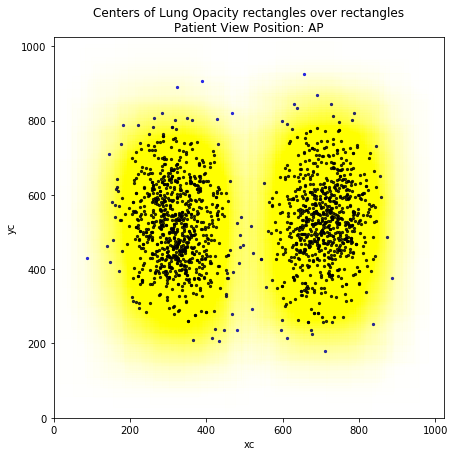

```python
plot_window(target_ap,'blue', 'yellow', 'Patient View Position: AP')
```

[figure not shown]

```python
plot_window(target_pa,'blue', 'green', 'Patient View Position: PA')
```

```python
print("Rows: train:",train_class_df['Rows'].unique(), "test:", test_class_df['Rows'].unique())
print("Columns: train:",train_class_df['Columns'].unique(), "test:", test_class_df['Columns'].unique())
```

```
Rows: train: [1024] test: [1024]
Columns: train: [1024] test: [1024]
```

```python
tmp = train_class_df.groupby(['Target', 'PatientAge'])['patientId'].count()
df = pd.DataFrame(data={'Exams': tmp.values}, index=tmp.index).reset_index()
tmp = df.groupby(['Exams','Target', 'PatientAge']).count()
df2 = pd.DataFrame(data=tmp.values, index=tmp.index).reset_index()
```

```python
tmp = train_class_df.groupby(['class', 'PatientAge'])['patientId'].count()
df1 = pd.DataFrame(data={'Exams': tmp.values}, index=tmp.index).reset_index()
tmp = df1.groupby(['Exams','class', 'PatientAge']).count()
df3 = pd.DataFrame(data=tmp.values, index=tmp.index).reset_index()
```

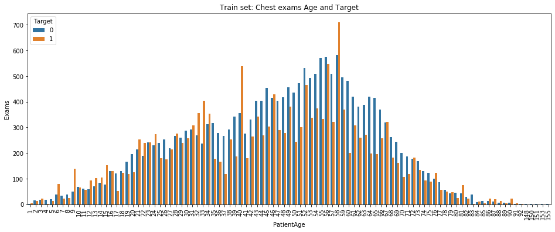

```python
fig, (ax) = plt.subplots(nrows=1,figsize=(16,6))
sns.barplot(ax=ax, x = 'PatientAge', y='Exams', hue='Target',data=df2)
plt.title("Train set: Chest exams Age and Target")
plt.xticks(rotation=90)
plt.show()
```

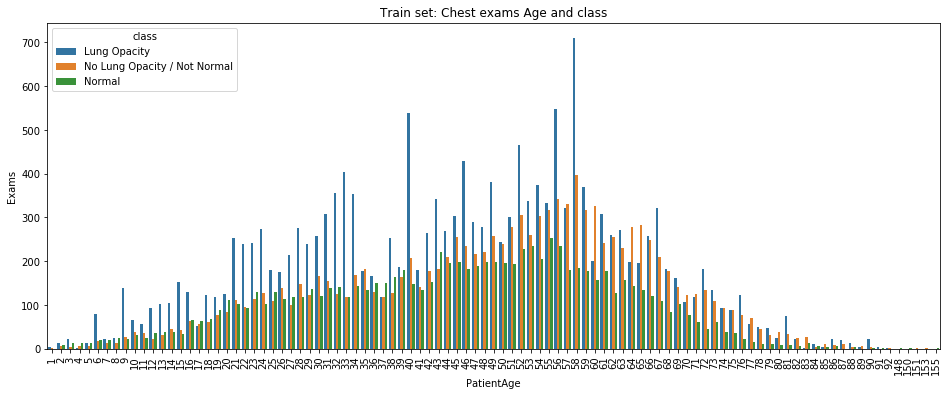

```python
fig, (ax) = plt.subplots(nrows=1,figsize=(16,6))
sns.barplot(ax=ax, x = 'PatientAge', y='Exams', hue='class',data=df3)
plt.title("Train set: Chest exams Age and class")
plt.xticks(rotation=90)
plt.show()
```

```python
# Looks Like the values of age 148 to 155 are mistakes.
```

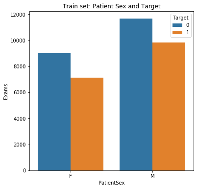

```python
tmp = train_class_df.groupby(['Target', 'PatientSex'])['patientId'].count()
df = pd.DataFrame(data={'Exams': tmp.values}, index=tmp.index).reset_index()
tmp = df.groupby(['Exams','Target', 'PatientSex']).count()
df2 = pd.DataFrame(data=tmp.values, index=tmp.index).reset_index()
fig, ax = plt.subplots(nrows=1,figsize=(6,6))
sns.barplot(ax=ax, x = 'PatientSex', y='Exams', hue='Target',data=df2)
plt.title("Train set: Patient Sex and Target")
plt.show()
```

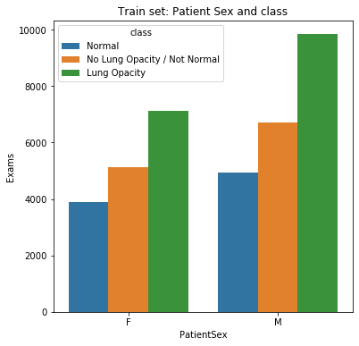

```python
tmp = train_class_df.groupby(['class', 'PatientSex'])['patientId'].count()
df1 = pd.DataFrame(data={'Exams': tmp.values}, index=tmp.index).reset_index()
tmp = df1.groupby(['Exams','class', 'PatientSex']).count()
df3 = pd.DataFrame(data=tmp.values, index=tmp.index).reset_index()
fig, (ax) = plt.subplots(nrows=1,figsize=(6,6))
sns.barplot(ax=ax, x = 'PatientSex', y='Exams', hue='class',data=df3)
plt.title("Train set: Patient Sex and class")
plt.show()
```

```python
#Anlayse Test DataSet
```

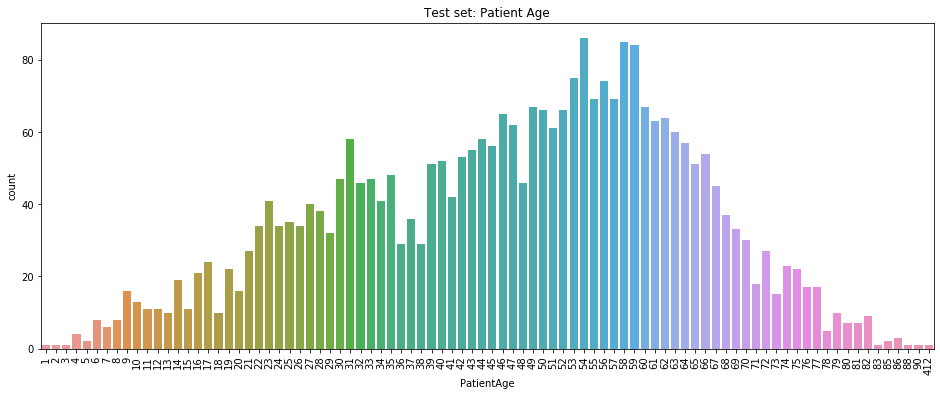

```python
fig, (ax) = plt.subplots(nrows=1,figsize=(16,6))
sns.countplot(test_class_df['PatientAge'], ax=ax)
plt.title("Test set: Patient Age")
plt.xticks(rotation=90)
plt.show()
```

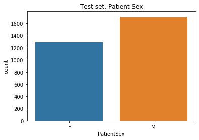

```python
sns.countplot(test_class_df['PatientSex'])
plt.title("Test set: Patient Sex")
plt.show()
```